# 8. Números racionales

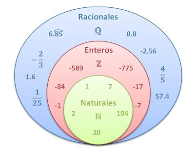

El conjunto de los números racionales engloba al de los enteros y naturales - Fuente: assets.sutori.com

**Aclaración:** 🔁 Las actividades marcadas con este símbolo tienen su solución al final. Para autocorregirte marca con **✓** los ejercicios que hiciste bien de entrada y con **✓✓** los que tuviste que corregir algún error. Buscar y entender los errores te ayudará a aprender mejor y podrás pasar las pruebas más fácil.

## ¿Qué son los números racionales?

Los **números racionales** son todos aquellos que se pueden expresar como una **fracción** del tipo $\frac{a}{b}$, donde:

- $a$ y $b$ son números enteros,
- $b \neq 0$.

> Ejemplos: $\frac{1}{2}$, $-\frac{3}{4}$, $5$ (es racional porque es $\frac{5}{1}$), $0,25$ (porque es $\frac{1}{4}$).

## 🔁 Actividad 1

Observa este fragmento de [video](https://www.youtubetrimmer.com/view/?v=RDn8UdSnN8Q&start=192&end=402&loop=0). Ahora que se supone entendiste cuales son los números racionales arma una lista con todos los números racionales que aparecen aquí: $\pi$; $\frac{3}{4}$; $\sqrt{2}$; $0{,}25$; $\frac{7}{1}$; $\sqrt{9}$; $2{,}5$; $\sqrt{3}$; $\frac{1}{3}$; $0{,}\overline{3}$; $\sqrt{16}$; $1{,}1\overline{6}$; $-\frac{5}{2}$

## La fracción como medida

Las fracciones pueden representar partes de una unidad.

**Ejemplo: Si un terreno mide 1 hectárea y sembramos 3/4 con soja, estamos usando una** fracción de medida**.

**Problema ejemplo:** Si una parcela mide 2 hectáreas y sembramos con soja $\frac{3}{4}$ de la parcela ¿Cuántas hectáreas representa lo sembrado?

**Vamos a resolverlo paso a paso:**

- Una parcela mide **2 hectáreas**.
- Queremos saber cuántas hectáreas representa $\frac{3}{4}$ de esa parcela.
- Multiplicamos la fracción por el total:

$$\frac{3}{4} \times 2 = \frac{3 \times 2}{4} = \frac{6}{4} = 1,5$$

- **Respuesta final:** Lo sembrado representa **1,5 hectáreas**

## 🔁 Actividad 2

Repasa [aquí](https://www.youtube.com/watch?v=I2cLyQSVQ4o) la multiplicación de una fracción por un número natural y resuelve paso a paso los siguientes problemas:

1. Hoy el tambo produjo $\frac{5}{8}$ de su capacidad diaria. Si su capacidad es de 1600 litros, ¿cuántos litros produjo hoy?
2. Un silo contiene $\frac{2}{5}$ de su capacidad total en maíz. Si el silo tiene capacidad para **2500 kilogramos**, ¿cuántos kilogramos de maíz contiene actualmente?
3. Un campo fue sembrado con girasol en $\frac{3}{10}$ de su superficie. Si el campo tiene 120 hectáreas, ¿cuántas hectáreas se sembraron con girasol?
4. Una cooperativa láctea procesa por día 1800 litros de leche. Hoy recibió solo el **$\frac{2}{3}$** de esa cantidad por la mañana, y por la tarde recibió el **$\frac{3}{4}$** de lo que había recibido por la mañana. **¿Cuántos litros recibió en total durante el día?**

## Orden en los números racionales $\mathbb{Q}$

Observa y estudia este [video](https://www.youtube.com/watch?v=KGH2FTyIldo) para aprender como se comparan las fracciones.

**Ejemplo:** ¿Qué es mayor: $\frac{3}{5}$ o $\frac{4}{7}$?

**Solución:**

Encontramos el mínimo común múltiplo de ambos denominadores:

- Tabla del 5: 5; 10; 15; 20; 25; 30; 35; 40; 45;
- Tabla del 7: 7; 14; 21; 28; 35; 42
- Vemos que el 35 está en ambos y es el mínimo común múltiplo

Construímos ambas fracciones con igual denominador

- $\frac{3 x 7}{5 x 7}$ = $\frac{21}{35}$
- $\frac{4 x 5}{7 x 5}$ = $\frac{20}{35}$

Como $\frac{21}{35}$ tiene mayor numerador esta es la mayor

**Respuesta:** La mayor es $\frac{3}{5}$

## 🔁 Actividad 3

1. Realiza el ejercicio que aparece en este fragmento de [video](https://www.youtubetrimmer.com/view/?v=KGH2FTyIldo&start=447&end=552&loop=0) pausándolo y luego comprobando el resultado.
2. Ordená de menor a mayor: $\frac{2}{3}, \frac{3}{5}, \frac{5}{8}$

## Actividad 4 (Opcional)

**Resuelve el siguiente problema:** En una escuela agrícola se están utilizando tres silos iguales para almacenar distintos granos. Cada silo tiene capacidad para **2400 kg**.

- En el **silo A**, se llenó $\frac{3}{4}$ con maíz. Luego se retiró $\frac{1}{3}$ de lo que había.
- En el **silo B**, se llenó $\frac{5}{6}$ con trigo. Luego se le agregó $\frac{1}{6}$ más del total del silo.
- En el **silo C**, se llenó primero $\frac{2}{5}$ con avena, y luego $\frac{3}{10}$ del total con cebada.

**Preguntas:**

1. ¿Cuántos kilogramos de grano hay actualmente en cada silo?
2. ¿Cuál silo tiene más cantidad de grano almacenado?

**Soluciones para autocorregirte**

### Actividad 1

Son números racionales: $\frac{3}{4}$; $0{,}25$; $\frac{7}{1}$; $\sqrt{9}$; $2{,}5$; $\frac{1}{3}$; $0{,}\overline{3}$; $\sqrt{16}$; $1{,}1\overline{6}$; $-\frac{5}{2}$

### Actividad 2

**a)** Multiplicamos la fracción por la capacidad:

$\frac{5}{8} \times 1600 = \frac{5 \times 1600}{8} = \frac{8000}{8} = 1000$

**Respuesta:** El tambo produjo **1000 litros** hoy.

**b)** Multiplicamos la fracción por la capacidad total:

$\frac{2}{5} \times 2500 = \frac{2 \times 2500}{5} = \frac{5000}{5} = 1000$

**Respuesta:** El silo contiene **1000 kilogramos** de maíz.

**c)**

$\frac{3}{10} \times 120 = \frac{3 \times 120}{10} = \frac{360}{10} = 36$

**Respuesta:** Se sembraron **36 hectáreas** con girasol.

**d)**

Leche recibida por la mañana:

$\frac{2}{3} \times 1800 = 1200 \text{ litros}$

Leche recibida por la tarde:

$\frac{3}{4} \times 1200 = 900 \text{ litros}$

Total recibido en el día:

$1200 + 900 = 2100 \text{ litros}$

**Respuesta:** La cooperativa recibió **2100 litros** en total durante el día.

### Actividad 3

2. **Respuesta final:** $\boxed{\frac{3}{5} < \frac{5}{8} < \frac{2}{3}}$